# 5. ggplot2（ロリポップ）_ex_key

Masahiko Asano

2022-08-10

- **このセクションで使っている `R packages`**

```r
library(DT)
library(gapminder)
library(gghighlight)
library(ggrepel)
library(stargazer)
library(tidyverse)
```

## 2. Exercise

**Q5.1:**  
`「1.1. 基本的なロリポップチャート」`の手法を使って、2009年の総選挙において都道府県内の小選挙区総数に占める民主党当選者の割合 (%) を示す新たな変数を作り、`dpj_ratio` と名前を付け、ロリポップチャートを描きなさい  
・データは hr96-21.csv をダウンロードして使うこと

```r
df_seat <- read_csv("data/hr09_14_ldp_seatshare.csv")
```

- まず、都道府県内の小選挙区総数に占める民主党当選者の割合 (%) を示す新たな変数を作り、`dpj_ratio` を作る

```r
DT::datatable(df_seat)
```

|  | year | pref | id | nosmd | ldp | ldp_ratio | dpj |
| --- | --- | --- | --- | --- | --- | --- | --- |
| 1 | 2012 | 愛知 | 1 | 15 | 13 | 87 | 2 |
| 2 | 2014 | 愛知 | 1 | 15 | 8 | 53 | 3 |
| 3 | 2009 | 愛知 | 1 | 15 | 0 | 0 | 15 |
| 4 | 2012 | 秋田 | 2 | 3 | 3 | 100 | 0 |
| 5 | 2014 | 秋田 | 2 | 3 | 3 | 100 | 0 |
| 6 | 2009 | 秋田 | 2 | 3 | 0 | 0 | 2 |
| 7 | 2012 | 青森 | 3 | 4 | 4 | 100 | 0 |
| 8 | 2014 | 青森 | 3 | 4 | 4 | 100 | 0 |
| 9 | 2009 | 青森 | 3 | 4 | 3 | 75 | 1 |
| 10 | 2012 | 千葉 | 4 | 13 | 11 | 85 | 2 |

[output cut: 131 more lines]

```r
df_seat <- df_seat |>
  mutate(dpj_ratio = dpj / nosmd * 100)

DT::datatable(df_seat)
```

|  | year | pref | id | nosmd | ldp | ldp_ratio | dpj | dpj_ratio |
| --- | --- | --- | --- | --- | --- | --- | --- | --- |
| 1 | 2012 | 愛知 | 1 | 15 | 13 | 87 | 2 | 13.3333333333333 |
| 2 | 2014 | 愛知 | 1 | 15 | 8 | 53 | 3 | 20 |
| 3 | 2009 | 愛知 | 1 | 15 | 0 | 0 | 15 | 100 |
| 4 | 2012 | 秋田 | 2 | 3 | 3 | 100 | 0 | 0 |
| 5 | 2014 | 秋田 | 2 | 3 | 3 | 100 | 0 | 0 |
| 6 | 2009 | 秋田 | 2 | 3 | 0 | 0 | 2 | 66.6666666666667 |
| 7 | 2012 | 青森 | 3 | 4 | 4 | 100 | 0 | 0 |
| 8 | 2014 | 青森 | 3 | 4 | 4 | 100 | 0 | 0 |
| 9 | 2009 | 青森 | 3 | 4 | 3 | 75 | 1 | 25 |
| 10 | 2012 | 千葉 | 4 | 13 | 11 | 85 | 2 | 15.3846153846154 |

[output cut: 131 more lines]

```r
df_seat_2009 <- df_seat %>%
  filter(year == 2009) |>
  ggplot(aes(x = dpj_ratio,
             y = reorder(pref, dpj_ratio))) + # dpj_ratio 順に pref を並べ替える
  geom_point(size = 2) +
  theme(panel.grid.major.x = element_blank(),
        panel.grid.minor.x = element_blank(),
        panel.grid.major.y = element_line(colour = "grey60", linetype = "dashed")) +
  theme_bw(base_family = "HiraKakuProN-W3") +
    labs(x = "民主党の議席率 (%)",
         y = "都道府県")
```

**Q1.2:**  
`「5.2 グループ分けしたロリポップチャート」`の手法を使って、2009年、2012年、2014年の総選挙において都道府県内の小選挙区総数に占める民主党当選者の割合 (%) をヒストグラムで描きなさい  
・データは hr96-21.csv をダウンロードして使うこと

```r
df_seat <- df_seat |>
  mutate(dpj_ratio = dpj / nosmd * 100)
```

```r
DT::datatable(df_seat)
```

|  | year | pref | id | nosmd | ldp | ldp_ratio | dpj | dpj_ratio |
| --- | --- | --- | --- | --- | --- | --- | --- | --- |
| 1 | 2012 | 愛知 | 1 | 15 | 13 | 87 | 2 | 13.3333333333333 |
| 2 | 2014 | 愛知 | 1 | 15 | 8 | 53 | 3 | 20 |
| 3 | 2009 | 愛知 | 1 | 15 | 0 | 0 | 15 | 100 |
| 4 | 2012 | 秋田 | 2 | 3 | 3 | 100 | 0 | 0 |
| 5 | 2014 | 秋田 | 2 | 3 | 3 | 100 | 0 | 0 |
| 6 | 2009 | 秋田 | 2 | 3 | 0 | 0 | 2 | 66.6666666666667 |
| 7 | 2012 | 青森 | 3 | 4 | 4 | 100 | 0 | 0 |
| 8 | 2014 | 青森 | 3 | 4 | 4 | 100 | 0 | 0 |
| 9 | 2009 | 青森 | 3 | 4 | 3 | 75 | 1 | 25 |
| 10 | 2012 | 千葉 | 4 | 13 | 11 | 85 | 2 | 15.3846153846154 |

[output cut: 131 more lines]

```r
str(df_seat$year)
```

```
 num [1:141] 2012 2014 2009 2012 2014 ...
```

- 変数 `year` が数値型なので `factor` に変換する

```r
df_seat$year <- factor(df_seat$year)
```

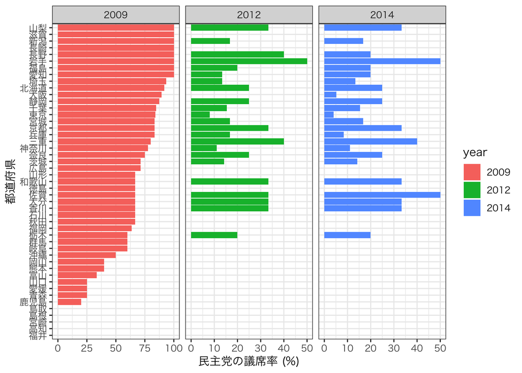

```r
df_seat %>%
  arrange(year, dpj_ratio) %>%
  mutate(order_seq = c(1:47, rep(0, 47*2))) %>% # `order_seq` という変数を加える

  ggplot(aes(x = reorder(pref, order_seq),
           y = dpj_ratio,
           fill = year)) +
  geom_bar(stat = "identity") +
  facet_grid(~ year, scales = "free_x") +
  theme(legend.position = "none") +
  coord_flip()+
  theme_bw(base_family = "HiraKakuProN-W3")+
    labs(x = "都道府県",
         y = "民主党の議席率 (%)")
```

**Q5.3:** この結果からどのようなことが言えるか？

- 民主党の議席は2012年と2014年に大きく減少している